# Exploratory Data Analysis

First, let's have a look some CSV, for example, the open price

```python
import pandas as pd
import numpy as np
import matplotlib.pyplot as plt
import matplotlib
matplotlib.rcParams['figure.figsize'] = (15.0, 7.5)

DATA_PATH='data/'
FIELDS={'open_p':'open_prices.csv',
        'close_p':'close_prices.csv',
        'high_p':'high_prices.csv',
        'low_p':'low_prices.csv',
        'volume':'volume.csv',
        'close_rtn':'close_returns.csv',
        'sign_a':'signals_A.csv','sign_b':'signals_B.csv'}
```

```python
#read open_prices, with time read as timestamps and index
open_p=pd.read_csv(DATA_PATH+FIELDS['open_p'],parse_dates=True,index_col='time')
print("Shape:",open_p.shape)
open_p.head()
```

```
Shape: (6518, 1000)
```

| time | A.0 | A.1 | A.2 | A.3 | A.4 | A.5 | A.6 | A.7 | A.8 | A.9 | ... | A.990 | A.991 | A.992 | A.993 | A.994 | A.995 | A.996 | A.997 | A.998 | A.999 |
| --- | --- | --- | --- | --- | --- | --- | --- | --- | --- | --- | --- | --- | --- | --- | --- | --- | --- | --- | --- | --- | --- |
| 2017-01-03 09:30:00 | 51.274744 | 53.171854 | 31.663986 | 8.403316 | 59.900866 | 62.050450 | 25.943284 | 2.227594 | 2.682416 | 4.182048 | ... | 4.991719 | 9.688353 | 32.592776 | 31.697389 | NaN | 58.667078 | 1.409677 | 49.989361 | 66.884724 | 5.080593 |
| 2017-01-03 09:45:00 | 50.611389 | 53.200903 | 31.524379 | 8.399806 | 59.230447 | 62.058988 | 25.500099 | 2.283807 | 2.577081 | 4.148389 | ... | 5.037104 | 9.604650 | 32.706852 | 32.372046 | NaN | 59.154650 | 1.409344 | 49.935643 | 67.227661 | 5.073182 |
| 2017-01-03 10:00:00 | 50.371401 | 52.780303 | 31.505340 | 8.257858 | 59.092719 | 63.061715 | 25.298993 | 2.270718 | 2.537952 | 4.056211 | ... | 5.029174 | NaN | 33.170525 | 31.863600 | NaN | 58.432837 | NaN | 50.071242 | 67.441024 | 5.124405 |
| 2017-01-03 10:15:00 | 50.314079 | 53.689222 | 32.070833 | 8.392878 | 58.637758 | 64.645491 | 24.977037 | 2.334489 | 2.555536 | 4.079543 | ... | 5.030521 | NaN | 33.220874 | 31.663718 | NaN | 58.489976 | 1.377389 | 50.524019 | 68.251130 | 5.115712 |
| 2017-01-03 10:30:00 | 50.480861 | 52.981277 | 32.244527 | 8.258612 | 58.869704 | 62.314744 | 25.445215 | NaN | 2.568765 | 4.052030 | ... | 5.076658 | 9.575618 | 33.332275 | 31.673093 | NaN | 58.717906 | 1.397458 | 49.696744 | 67.760805 | 5.041244 |

5 rows × 1000 columns

```python
open_p.tail()
```

| time | A.0 | A.1 | A.2 | A.3 | A.4 | A.5 | A.6 | A.7 | A.8 | A.9 | ... | A.990 | A.991 | A.992 | A.993 | A.994 | A.995 | A.996 | A.997 | A.998 | A.999 |
| --- | --- | --- | --- | --- | --- | --- | --- | --- | --- | --- | --- | --- | --- | --- | --- | --- | --- | --- | --- | --- | --- |
| 2017-12-29 14:45:00 | 63.394039 | 54.210834 | 14.404904 | 10.373690 | 95.677114 | 35.912002 | 42.958602 | 4.338909 | 2.010338 | 2.946883 | ... | 5.363419 | NaN | 39.155696 | NaN | NaN | 67.704994 | 1.471387 | 63.082895 | 65.279762 | 16.382219 |
| 2017-12-29 15:00:00 | 62.990818 | 53.724463 | 14.532009 | 10.403841 | 95.013357 | 36.574458 | 42.688857 | 4.286772 | 2.055957 | 2.931272 | ... | 5.402689 | NaN | 39.400322 | NaN | NaN | 68.624883 | NaN | 62.201247 | 65.083676 | 16.194330 |
| 2017-12-29 15:15:00 | 63.345985 | 54.706220 | 14.644313 | 10.470148 | 94.681537 | 36.447575 | 43.213201 | 4.332350 | 2.048128 | 2.888139 | ... | 5.430365 | NaN | 39.729554 | NaN | NaN | 68.398528 | NaN | 62.857382 | 65.192478 | 16.245067 |
| 2017-12-29 15:30:00 | 63.135582 | 54.610595 | 14.750768 | 10.353600 | 95.561447 | 36.548715 | 42.913302 | 4.365268 | 2.034877 | 2.882221 | ... | 5.386654 | NaN | 39.101702 | NaN | NaN | 68.292000 | 1.458053 | 62.293168 | 64.814582 | 16.029266 |
| 2017-12-29 15:45:00 | 63.876417 | 54.539958 | 14.750365 | 10.267512 | 95.753547 | 36.512714 | 43.260446 | 4.380972 | 1.997167 | 2.893691 | ... | 5.402177 | NaN | 39.582676 | NaN | NaN | 67.279699 | 1.483510 | 62.933620 | 65.528375 | 15.862938 |

5 rows × 1000 columns

Each feature (`open`, `close`, `high`, `low`, `volume` - `OCHLV`) is stored in one file. Each file has 1000 columns corresponding to 1000 stocks. There are in total $6518$ rows, corresponding to $6518$ intervals (of 15 minutes each)from the begining to the end of the year 2017.

It is a bit uneasy to have different values/signals in different files. Let's merge them all into one dataframe with the format

`time,stock_name,open,close,high,low,volume,close_rtn`

```python
stock_data=pd.DataFrame()
for k,v in FIELDS.items():
    data=pd.read_csv(DATA_PATH+v,parse_dates=True,index_col='time')

    #convert to long format, i.e., one stock in a row
    data['t']=data.index
    data=pd.wide_to_long(data,'A.',i='t',j='s')
    data.columns=[k] #rename the column to relevant name

    #each 'data' is equivalent to a column in the final table, append to the main table
    stock_data=data if stock_data.empty else pd.merge(stock_data,data,left_index=True,right_index=True)

#verify the final table
stock_data.head()
```

| t | s | open_p | close_p | high_p | low_p | volume | close_rtn | sign_a | sign_b |
| --- | --- | --- | --- | --- | --- | --- | --- | --- | --- |
| 2017-01-03 09:30:00 | 0 | 51.274744 | 51.024482 | 51.486503 | 50.884913 | 73726.0 | NaN | NaN | NaN |
| 2017-01-03 09:45:00 | 0 | 50.611389 | 50.487200 | 50.668706 | 50.487200 | 45661.0 | -0.010530 | -0.012937 | NaN |
| 2017-01-03 10:00:00 | 0 | 50.371401 | 50.223740 | 50.433324 | 50.157150 | 64689.0 | -0.005218 | -0.004742 | NaN |
| 2017-01-03 10:15:00 | 0 | 50.314079 | 50.447513 | 50.485636 | 50.275955 | 30121.0 | 0.004456 | -0.001138 | NaN |
| 2017-01-03 10:30:00 | 0 | 50.480861 | 50.356760 | 50.576325 | 50.356760 | 26289.0 | -0.001799 | 0.003315 | NaN |

```python
# Let's further verify the aggregated table

print(stock_data.info())
print("Shape: {}".format(stock_data.shape))
```

```
<class 'pandas.core.frame.DataFrame'>
MultiIndex: 6518000 entries, (2017-01-03 09:30:00, 0) to (2017-12-29 15:45:00, 999)
Data columns (total 8 columns):
open_p       float64
close_p      float64
high_p       float64
low_p        float64
volume       float64
close_rtn    float64
sign_a       float64
sign_b       float64
dtypes: float64(8)
memory usage: 423.1 MB
None
Shape: (6518000, 8)
```

The aggregated data now is stored in a long table, where each row corresponds to a (<timestamp>,<stock>). There are in total $6,518,000$ rows (= $1000$ stocks x $6518$ intervals as above)

Time and stock name columns are used as indices of the dataframe. This makes it a bit inconvenient to access. Let's replicate those two columns for easier access.

```python
stock_data['stock']=stock_data.index.get_level_values('s')
stock_data['time']=stock_data.index.get_level_values('t')
```

Let's have a closer look at the quality of the data. One of the most important things to verify is whether the data contains a lot of missing values.

```python
stock_data.isna().sum()
```

```
open_p       790350
close_p      790350
high_p       790350
low_p        790350
volume       745526
close_rtn    929242
sign_a       929242
sign_b       815673
stock             0
time              0
dtype: int64
```

It looks like there are more than 10% of data is NA. Further analysis shows that:

1. Some stocks have more `NaN` than the others. The reason maybe due to different votality, stock being listed recently, etc.? Without the actual names of the stocks, finding the reasons of these `NaN` is not relevant to this task.
2. The `NaN` values are scattered throughout the day, they appear less frequently at open and close

For this task, let's just drop the NaNs. It might also be possible to backfill the NaNs `close_rtn` with $0$.

```python
count_nans=stock_data.groupby(['stock']).count().sort_values(by='close_rtn')

count_nans.head()
```

| stock | open_p | close_p | high_p | low_p | volume | close_rtn | sign_a | sign_b | time |
| --- | --- | --- | --- | --- | --- | --- | --- | --- | --- |
| 168 | 32 | 32 | 32 | 32 | 53 | 0 | 0 | 0 | 6518 |
| 994 | 57 | 57 | 57 | 57 | 353 | 1 | 1 | 0 | 6518 |
| 149 | 126 | 126 | 126 | 126 | 200 | 4 | 4 | 0 | 6518 |
| 956 | 143 | 143 | 143 | 143 | 179 | 6 | 6 | 0 | 6518 |
| 926 | 134 | 134 | 134 | 134 | 274 | 6 | 6 | 0 | 6518 |

```python
count_nans.tail()
```

| stock | open_p | close_p | high_p | low_p | volume | close_rtn | sign_a | sign_b | time |
| --- | --- | --- | --- | --- | --- | --- | --- | --- | --- |
| 459 | 6504 | 6504 | 6504 | 6504 | 6508 | 6501 | 6501 | 6499 | 6518 |
| 463 | 6504 | 6504 | 6504 | 6504 | 6507 | 6501 | 6501 | 6498 | 6518 |
| 447 | 6504 | 6504 | 6504 | 6504 | 6506 | 6501 | 6501 | 6497 | 6518 |
| 499 | 6504 | 6504 | 6504 | 6504 | 6508 | 6501 | 6501 | 6499 | 6518 |
| 47 | 6505 | 6505 | 6505 | 6505 | 6504 | 6502 | 6502 | 6486 | 6518 |

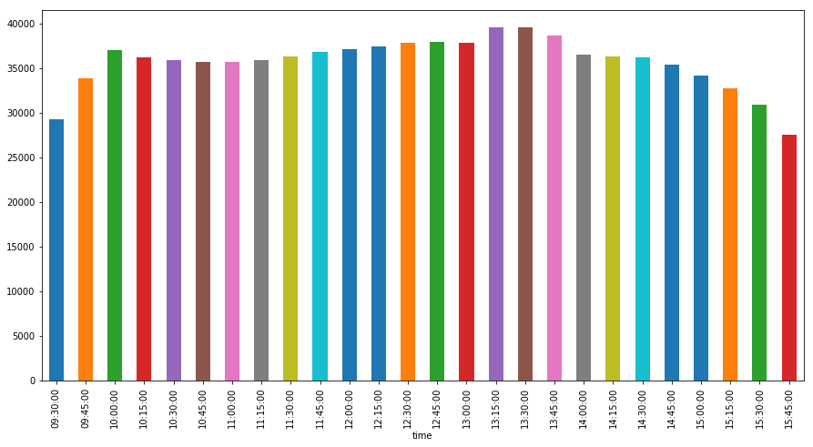

```python
#Verify a few stocks to see where the NaN occurs:
when_na=stock_data[['close_rtn','time']].loc[(stock_data['close_rtn'].isnull()),:].groupby(stock_data['time'].dt.time).size()
when_na.plot(kind='bar',y='Number of NaNs')
plt.show()
```

To get a better idea of the dataset, let's plot:

```
Text(0,0.5,'Values')
```

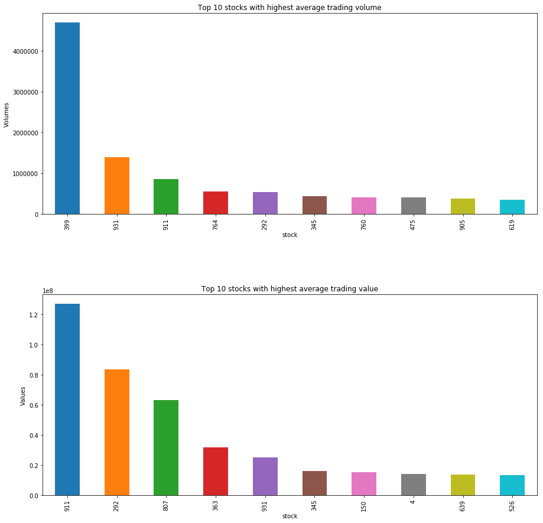

```python
grpby_stock=stock_data.groupby('stock')

# 1. Top 10 stocks with highest average trading volume
top10_avg_vol=grpby_stock['volume'].mean().nlargest(10)

# 2. Top 10 stocks with highest average trading value
top10_avg_value=grpby_stock.apply(lambda x:np.mean(x['volume']*(x['open_p']+x['open_p'])/2))
top10_avg_value=top10_avg_value.nlargest(10)

fig, axes = plt.subplots(nrows=2, ncols=1, figsize=(15,15))
fig.subplots_adjust(hspace=0.4)

top10_avg_vol.plot(kind='bar',ax=axes[0],title='Top 10 stocks with highest average trading volume', y='Volumes')
top10_avg_value.plot(kind='bar',ax=axes[1], title='Top 10 stocks with highest average trading value', y='Value')

axes[0].set_ylabel('Volumes')
axes[1].set_ylabel('Values')
```

```
Text(0,0.5,'% change')
```

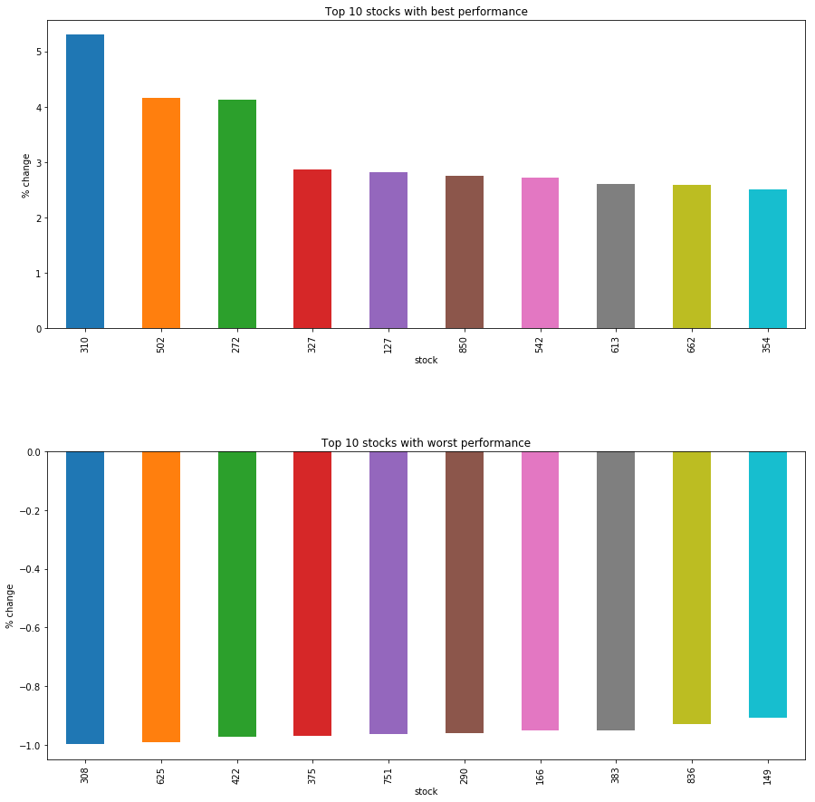

```python
stock_movement=(grpby_stock['close_p'].last()-grpby_stock['open_p'].first())/grpby_stock['open_p'].first()

# 3. Top 10 stocks with best performance
best_10=stock_movement.nlargest(10)

# 4. Top 10 stocks with worst performance
worst_10=stock_movement.nsmallest(10)

fig, axes = plt.subplots(nrows=2, ncols=1, figsize=(15,15))
fig.subplots_adjust(hspace=0.4)

best_10.plot(kind='bar',ax=axes[0],title='Top 10 stocks with best performance')
worst_10.plot(kind='bar',ax=axes[1], title='Top 10 stocks with worst performance')

axes[0].set_ylabel('% change')
axes[1].set_ylabel('% change')
```

The task is to make prediction on `close_rtn`. Let's drill down and analyze one stock to make sense of `close_rtn`, `sign_a`, `sign_b`.

(With no explanation on what signal `sign_a`, `sign_b` are, maybe it's best not to use them for now.)

Plot to see how the `close_rtn` changes as the stock increaes/decreases. It should indicate how much (in terms of ratio) the stock increases/decreseas since the last checkpoint.

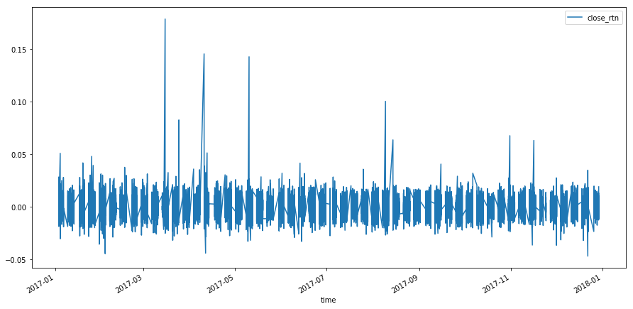

```python
stock_data.loc[stock_data['stock']==354,:].plot(x='time',y='close_rtn')
```

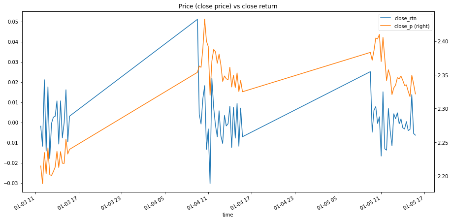

```python
# Let's take closer look in a shorter timeframe to see how the values change together
stock_354=stock_data.loc[stock_data['stock']==354,:]
stock_354.index=stock_354['time']
stock_354=stock_354.dropna()

#Plot only a small segment to see the change in close up
fig,ax=plt.subplots(1,1)

stock_354.loc['2017-01-03':'2017-01-05'].plot(x='time',y='close_rtn',ax=ax,title='Price (close price) vs close return')
stock_354.loc['2017-01-03':'2017-01-05'].plot(x='time',y='close_p',secondary_y=True,ax=ax)
```

# Manual prediction using ARIMA

Before making prediction, it is necessary to analyze the stationarity of the timeseries. This is necessary because most prediction models (including the one used in this task - ARIMA) assume the stationarity of the time series. For a stationry time series, the models work on the assumption that the behaviour will repeat in the future

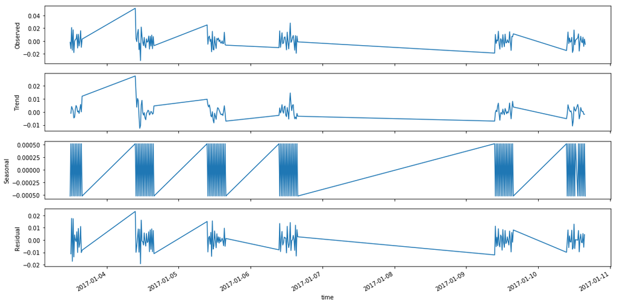

```python
#Pick a few stocks to visually check if the stationarity of the data
from statsmodels.tsa.seasonal import seasonal_decompose
import matplotlib.dates as mdates
import matplotlib.ticker as ticker
import datetime

seasonal_decompose(stock_354['close_rtn'].loc['2017-01-03':'2017-01-10'],freq=2).plot()
plt.show()
```

It is not very clear visually whether the time series of this stock is stationary, although it looks like there is no trend (stays near 0).

In addition, we need to have a way to automatically test the stationarity of all the stocks in a more automatic way. This needs to be done before we can apply the prediction model for each stock. To this end, Augmented Dickey-Fuller Test can be used.

More information can be found here: https://en.wikipedia.org/wiki/Augmented_Dickey%E2%80%93Fuller_test

The null hypothesis of the Augmented Dickey-Fuller (ADF) is that there is a unit root (non stationary), with the alternative that there is no unit root (the time series is stationary). If the pvalue is above a confidence level, then the time series is non-stationary.

Below is a function that takes the series, performs the ADF test and output whether the time series of each stock is stationry.

With the confidence level of $1%$, the test indicates that only 3 (out of 1000 stocks) are non stationary. It is safe to assume that the movements of `close_rtn` of most of the stocks are stationary.

We can proceed building the model.

```python
from statsmodels.tsa.stattools import adfuller
def is_stationarity(series,conf_level=5):
    series=series.dropna()
    try:
        tests = adfuller(series)

        #compare the test statistics vs the according critical value
        test_statistic=tests[0]
        critical_val=tests[4]['{}%'.format(conf_level)]

        return True if test_statistic<critical_val else False
    except ValueError:
        return None

    return False
```

```python
test_stationarity=grpby_stock.apply(lambda x:is_stationarity(x['close_rtn'],1))
```

```python
print("Number of non-stationary series: "+str(np.sum(test_stationarity == False)))
```

```
Number of non-stationary series: 3
```

## PREDICTION Using ARIMA.

More details of ARIMA can be found [here](https://en.wikipedia.org/wiki/Autoregressive_integrated_moving_average)

Once we confirm the time series are stationary, an important task is to choose the parameters `p`, `d`, `q` for the algorithm.

Setting the values of `p`, `d`, `q` can be a problem because the meaning of each parameter is not very intuitive. Let's use a **grid search** to find the best parameters.

```python
import itertools
import warnings
warnings.filterwarnings("ignore")
p=range(0,4)
d=range(0,4)
q=range(0,4)
pdq = list(itertools.product(p, d, q))

#It's is likely the close return of the first months of the year will not affect
#the close return of the current month.

#Let's make the prediction based on only the last month
stock_354=stock_data.loc[stock_data['stock']==354,:]
stock_354.index=stock_354['time']
stock_354=stock_354.dropna()
close_rtn_354=stock_354['close_rtn']
close_rtn_354=close_rtn_354.loc['2017-11-01':'2017-11-30']

best_params=pdq[0]
smallest_aic=float("inf")

for params in pdq:
    try:
        #the time series is already stationary
        model= tsa.statespace.SARIMAX(close_rtn_354.values, order=params)

        results = model.fit()
        if results.aic<smallest_aic:
            smallest_aic=results.aic
            best_params=params
    except Exception as e:
        continue

print((0,0,2))
```

```
(0, 0, 2)
```

```python
results.aic
```

```
-33719.12794463308
```

Let's perofrm the ARIMA prediction and plot the predicted values together with the actual values.

```
Text(0.5,1,'RMSE: 0.00819905547784339')
```

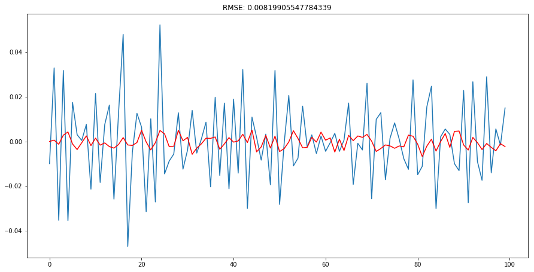

```python
#from statsmodels.tsa.arima_model import ARIMA
from statsmodels.api import tsa
from sklearn.metrics import mean_squared_error
#model = tsa.statespace.SARIMAX(close_rtn_354.values, order=(1, 0, 3))
model = tsa.statespace.SARIMAX(close_rtn_354.values, order=(0, 0, 2))
results_AR = model.fit(disp=-1)
plt.plot(close_rtn_diff.values[:100])
plt.plot(results_AR.fittedvalues[:100], color='red')
plt.title(f'RMSE: {np.sqrt(mean_squared_error(close_rtn_354.values,results_AR.fittedvalues))}')
```

The RMSE error is pretty small (0.00819). Another analysis of the prediction result is shown below.

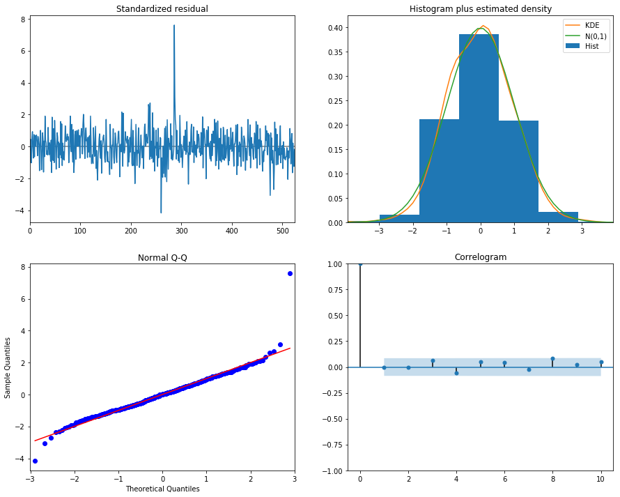

```python
results_AR.plot_diagnostics(figsize=(15, 12))
plt.show()
```

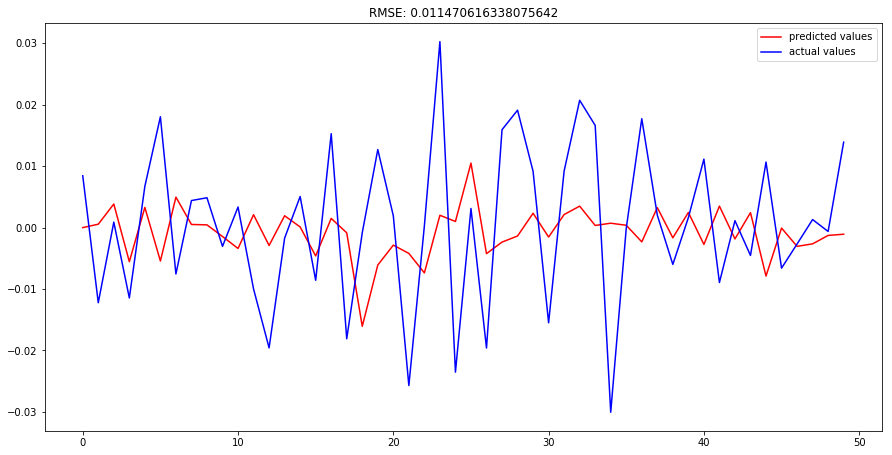

```python
#The values need to be re-initialized
stock_354=stock_data.loc[stock_data['stock']==354,:]
stock_354.index=stock_354['time']
stock_354=stock_354.dropna()
close_rtn_354=stock_354['close_rtn']

training_set=close_rtn_354.loc['2017-01-01':'2017-01-30']
test_set=close_rtn_354.loc['2017-02-01':'2017-02-15']
model = tsa.statespace.SARIMAX(training_set.values,order=(1,0,3)).fit()

predicted = model.predict(start=0,end=len(test_set)-1)
plt.plot(predicted[:50],color='red',label='predicted values')
plt.plot(test_set.values[:50],color='blue',label='actual values')
plt.title(f'RMSE: {np.sqrt(mean_squared_error(test_set.values,predicted))}')
plt.legend()
plt.show()
```

The line does not match very nicely in some cases. The RMSE is still not very high.

The next step is to come up with functions that automate the end-to-end prediction.